# Phase 1 and 2 Analysis Including Collatz Conjecture and Diamonds Data

Katie Clayton

2022-11-04

# **Collatz Conjecture**

#### Intro to Collatz Conjecture

The collatz conjecture is used to transform every positive integer into one. Two arithmetic equations are input using if statements and else if statements in order to get to the integer one. If the number is even, the function will use the number and divide it by two. If the number is odd, it will be multiplied by three and added to one. Once the number gets to one, the function will stop. The purpose is to find out the most frequent stopping time based off this function.

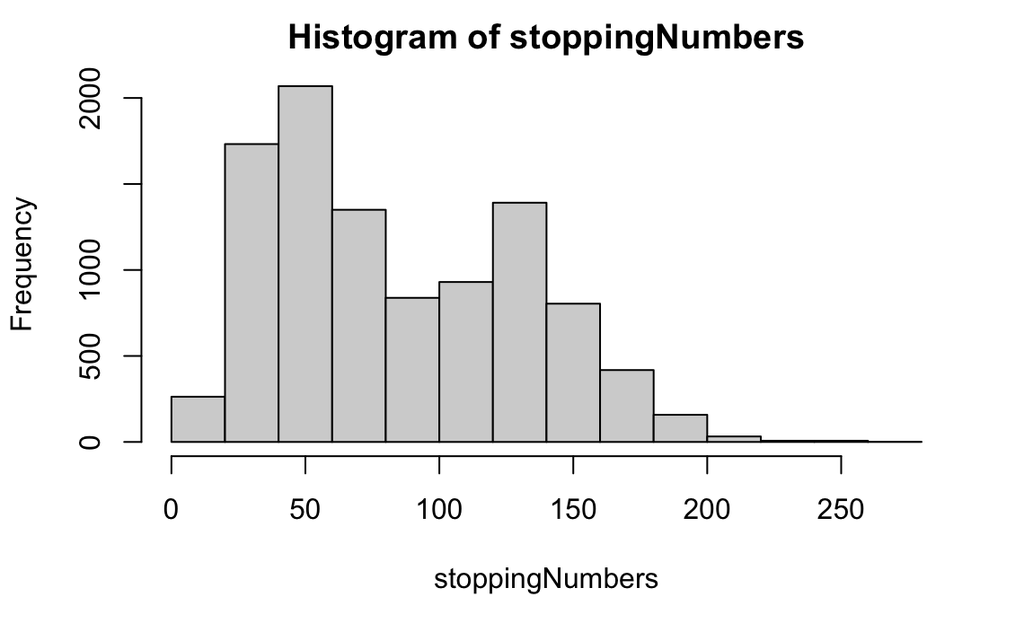

```r
#name function and add nouns
getCollatz <- function(number,count=0)
  #first part of collatz conjecture, when number is 1
{if (number == 1){
  return (count)}
  #when number is even, divide by two
  else if (number%%2==0)
    {getCollatz(number/2,count+1)}
  #when number is odd, multiply by 3 and add 1
  else{
    getCollatz(number*3+1,count+1)}}
# create function for histogram
stoppingNumbers <- sapply(
# label x axis and incldue function that needs to be called
X = 1:10000,
FUN = getCollatz
)
# make the histogram
hist(stoppingNumbers)
```

#### Figure 1. Histogram of The Most Frequent Stopping Numbers For The Collatz Conjecture